# Ecossistemas Empreendedores e Sistemas Regionais de Inovação

Empreendedorismo Tecnológico e Desenvolvimento Territorial · Aula 03

Prof. Dr. Luiz Diego Vidal Santos

## Unidade I Visão geral da aula

**01 · Evolução conceitual:** Dos Sistemas de Inovação (SNI/SRI) aos Ecossistemas Empreendedores.

**02 · Isenberg (2010; 2011):** Os 6 domínios e os princípios de intervenção territorial.

**03 · Stam (2015; 2021):** Condições estruturais, sistêmicas, *outputs* e *outcomes*.

**04 · Boschma (2005):** O Paradoxo da Proximidade e os riscos de *lock-in* regional.

**05 · Crítica periférica:** Viés das *gazelles* e diagnóstico de ecossistemas fora do centro.

Propósito formativo Objetivo da aula

Compreender a arquitetura conceitual e empírica dos **ecossistemas empreendedores** e dos **Sistemas Regionais de Inovação (SRI)**, diferenciando seus elementos estruturais, mecanismos de retroalimentação e implicações para políticas territoriais.

SRI · Cooke Isenberg & Stam Proximidade · Boschma

**Pergunta-chave:** Por que instituições científicas fortes não bastam, sozinhas, para gerar um ecossistema empreendedor dinâmico no território?

# Evolução Conceitual

## Conceito Sistemas de Inovação vs. Ecossistemas Empreendedores

Cooke et al. (1997) Sistemas Regionais de Inovação (SRI)

- Foco nas **instituições de P&D, firmas estabelecidas e políticas tecnológicas**.
- Ênfase na geração e difusão de conhecimento em rede.
- O empreendedor aparece muitas vezes como ator secundário diante de grandes empresas e laboratórios.

Spigel (2017); Stam (2015) Ecossistemas Empreendedores

- Coloca o **empreendedor inovador no centro** do sistema, não apenas como resultado, mas como agente construtor.
- Conjunto de atores interdependentes e fatores coordenados de modo a permitir o **empreendedorismo produtivo** (*ambitious entrepreneurship*) em um território específico.

**Síntese:** Enquanto o SRI explica a capacidade de *produzir conhecimento*, o Ecossistema Empreendedor explica a capacidade do território de *transformar conhecimento em novos negócios escaláveis*.

# Modelos Analíticos de Ecossistemas

## Conceito Os 6 domínios de Isenberg (2011)

Babson Entrepreneurship Ecosystem Project Os 6 domínios interdependentes

1. **Políticas (*Policy*):** liderança governamental e marco regulatório.
2. **Finanças (*Finance*):** microcrédito, anjos, *venture capital*, fomento.
3. **Cultura (*Culture*):** tolerância ao risco/erro, histórias de sucesso, status social.
4. **Suporte (*Supports*):** infraestrutura, incubadoras, serviços jurídicos e contábeis.
5. **Capital Humano (*Human Capital*):** universidades, formação técnica, empreendedores seriais.
6. **Mercados (*Markets*):** redes de clientes iniciais (*early adopters*) e canais de distribuição.

**01 · Não copie o Vale do Silício:** cada território deve construir sobre suas vocações e ativos locais (Isenberg, 2010).

**02 · Evite “elefantes brancos”:** infraestrutura física sem demanda empreendedora real fracassa.

**03 · Reciclagem empreendedora:** empreendedores bem-sucedidos reinvestem capital, mentoria e reputação no próprio território.

Os seis domínios atuam como sistema acoplado: avançar em apenas um pilar sem os demais gera gargalos.

## Síntese Modelo causal de ecossistema empreendedor

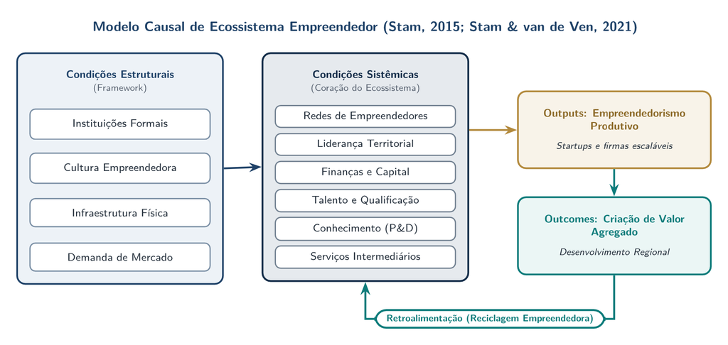

Estrutura integrativa de Stam (2015) e Stam & van de Ven (2021): condições estruturais, condições sistêmicas, outputs empreendedores e outcomes regionais.

Modelo causal de ecossistema empreendedor (Stam, 2015; Stam & van de Ven, 2021) Integração entre condições estruturais, condições sistêmicas, empreendedorismo produtivo e retroalimentação regional

A criação de valor agregado realimenta as condições sistêmicas ao longo do tempo por meio da reciclagem empreendedora.

## Conceito O modelo integrativo de Stam (2015; 2021)

Arquitetura em dois níveis Condições estruturais × sistêmicas

- **Condições estruturais (*Framework*):** instituições formais, cultura, infraestrutura física e demanda de mercado.
- **Condições sistêmicas (Coração do ecossistema):**
  1. Redes de empreendedores; 2. Liderança;
  2. Finanças; 4. Talento;
  3. Conhecimento; 6. Serviços intermediários.

Dinâmica de resultados Outputs, outcomes e retroalimentação

- *Outputs*: empreendedorismo produtivo (novas firmas inovadoras, de alto crescimento ou alto impacto).
- *Outcomes*: criação agregada de valor, produtividade e desenvolvimento econômico regional.
- **Causalidade ascendente e descendente:** retroalimentação contínua entre resultados e condições sistêmicas.

**Vantagem metodológica:** O modelo de Stam permite construir **índices compostos comparativos** entre municípios ou regiões (ex.: Índice de Ecossistemas Empreendedores).

# Proximidade e Território

## Território As 5 dimensões da proximidade (Boschma, 2005)

| Dimensão | O que significa | Risco do Excesso (*Lock-in*) |
| --- | --- | --- |
| **Geográfica** | Distância física entre atores | Isolamento de fluxos externos |
| **Cognitiva** | Base de conhecimento compartilhada | Falta de diversidade / novidade |
| **Organizacional** | Vínculos hierárquicos ou em rede | Burocratização e dependência |
| **Social** | Relações de confiança e amizade | Endogamia e fechamento |
| **Institucional** | Regras formais e informais comuns | Inércia institucional |

Implicação para o planejamento Proximidade geográfica não basta

A proximidade física facilita o encontro, mas a cooperação tecnológica exige **proximidade cognitiva e institucional** mínima entre os atores.

Políticas territoriais devem construir **“pontes externas” (*pipelines* globais)** para evitar o aprisionamento regional (*regional lock-in*).

## Crítica Paradoxo da proximidade e viés das gazelles

1 · Boschma (2005) e Dosi (1982) O paradoxo da proximidade e o lock-in

- Estar junto fisicamente não garante inovação e pode produzir **estagnação territorial**.
- **Conexão Kuhn–Dosi–Boschma:** quando firmas, ensino técnico e órgãos públicos operam apenas na “ciência normal” de uma trajetória antiga (petroquímica fóssil ou monocultura convencional), o excesso de proximidade cognitiva e institucional gera **cegueira tecnológica (*lock-in*)**.
- Transitar para **bioeconomia ou energias renováveis na Bahia** exige combinar ativos locais com novos paradigmas e *pipelines* globais.

2 · Stam vs. periferias Crítica ao viés das gazelles

- Modelos canônicos de ecossistemas (Isenberg; Stam) medem sucesso quase exclusivamente pela geração de *startups* de hipercrescimento (*gazelles* / unicórnios).
- Em regiões periféricas e no interior brasileiro, esse viés ignora cooperativas inovadoras, PMEs intensivas em conhecimento local e negócios de impacto que retêm renda e emprego no território.

# Oficina de Diagnóstico

## Método Mapeamento de ecossistema e leituras

Oficina diagnóstica (45 min) Feira de Santana / Portal do Sertão

Em grupos, avaliem de **1 a 5** os 6 elementos sistêmicos de Stam (2021) para o território escolhido:

1. Redes e eventos empreendedores · 2. Liderança articuladora · 3. Financiamento e fomento · 4. Talento e formação superior/técnica · 5. Produção de conhecimento (P&D/PI) · 6. Serviços de suporte (incubadoras, contabilidade, NITs).

**Entregável:** Identificar o **principal gargalo sistêmico** e propor 1 ação concreta de governança territorial.

Bibliografia fundamental Leituras da Aula 03 e próxima aula (Eixos 2 e 3)

- **ISENBERG, D.** *How to start an entrepreneurial revolution*. HBR, 2010; **LUNDVALL, B.-Å.** *National systems of innovation*, 1992.
- **STAM, E.; VAN DE VEN, A.** *Entrepreneurial ecosystem elements*. Small Business Economics, 2021.
- **BOSCHMA, R.** *Proximity and innovation: a critical assessment*. Regional Studies, 2005.
- **ETZKOWITZ, H.; LEYDESDORFF, L.** *The dynamics of innovation: Triple Helix*. Research Policy, 2000.
- **MAZZUCATO, M.** *O Estado empreendedor*. Portfolio-Penguin, 2014; **FORAY, D.** *Smart Specialisation*, 2015.